# 8.3 Principal Component Analysis and the Autoencoder

code

share

8.3 Principal Component Analysis and the Autoencoder

The most fundamental *unsupervised learning* method - known as *Principal Component Analysis* (or *PCA* for short) follows directly from our discussion in the previous Section regarding fixed basis representations with one crucial caveat: now we aim to learn not only the best linear combination of a set of $K \leq N$ spanning vectors to represent $N$ dimensional points as best as possible, but the best set of spanning vectors themselves as well. For such datasets PCA is often used to learn a lower dimensional $K < N$ representation that is easier for human beings to interpret. Another very important application of PCA is to data normalization / feture scaling, where PCA is used to learn a complete $K=N$ dimensional spanning set, to which we dedicate the entirety of the Section following this one.

In this Section take an in depth look at PCA, beginning with a discussion about how to learn a general $K$ dimensional basis for a given dataset. Then - following the discussion of the previous Section - we look at the problem of learning *orthogonal* bases via the so-called *autoencoder*. This then leads to the our final discussion of the classic orthogonal PCA basis - a very special global minimum of the autoencoder cost function - in the final part of the Section.

## 8.3.1 PCA and learning proper spanning sets

Imagine we return to the previous Section where we discussed how - given a fixed basis or spanning set of $K \leq N$ vectors $\mathbf{c}_1,\,\mathbf{c}_2,...,\mathbf{c}_K$ - we can represent a set of $P$ mean-centered points $\mathbf{x}_1,\,\mathbf{x}_2,...,\mathbf{x}_P$ as

\begin{equation} \sum_{n=1}^K \mathbf{c}_n w_{n,\,p} \approx \mathbf{x}_p \,\,\,\,\,\,\,\,\,\,\,\,\,\,\,\,\,\,\,\,\,\,\,\, p=1...P \end{equation}

tuning the weights $w_{p,n}$ by minimizing a Least Squares cost function

\begin{equation} g\left(\mathbf{w}_1,...,\mathbf{w}_P\right) = \frac{1}{P}\sum_{p = 1}^P \left \Vert \mathbf{C}\mathbf{w}_p - \mathbf{x}_p \right\Vert_2^2. \end{equation}

In general when we used a full set of *linearly independent* $K = N$ fixed basis vectors we can learn corresponding weights that drive this cost function to zero, and give us strict equality in equation (1).

In the previous Section we supposed that our spanning set / basis $\mathbf{C}$ was *fixed*. However here we will *learn* a proper basis (along with the weights). This slight thematic twist - where we *learn* the basis along with the proper weights - is called *Principal Component Analysis*.

How can we *learn* a proper basis for a given dataset? Well, we can imagine that with an ideal basis $\mathbf{C}$ and properly tuned our weight vectors / encodings $\mathbf{w}_p$ we could drive the value of the Least Squares error above even lower than we could with any fixed basis (since at least in principle we should be able to learn a basis that provides just as small of an error as any fixed one). In other words, to learn a quality basis $\mathbf{C}$ we should be *minimizing* the cost function above over $\mathbf{C}$ as well as the weight vectors / encodings $\mathbf{w}_1,\,...,\mathbf{w}_P$.

Adding $\mathbf{C}$ to the list of optimization variables we need to minimize with respect to, this Least Squares cost function takes the similar form

\begin{equation} g\left(\mathbf{w}_1,...,\mathbf{w}_P,\mathbf{C}\right) = \frac{1}{P}\sum_{p = 1}^P \left \Vert \mathbf{C}\mathbf{w}_p - \mathbf{x}_p \right\Vert_2^2. \end{equation}

Again - the only thing that has changed here is that now (since we aim to learn the basis $\mathbf{C}$ as well, it has been added to the list of variables we wish to minimize the original Least Squares cost function with respect to. The formal problem of minimizing this Least Squares cost over the basis and encoding vectors can then be written as

\begin{equation} \underset{\mathbf{w}_1,\mathbf{w}_2,...,\mathbf{w}_P,\mathbf{C}}{\text{minimize}} \,\, \frac{1}{P}\sum_{p = 1}^P \left \Vert \mathbf{C}\mathbf{w}_p - \mathbf{x}_p \right\Vert_2^2. \end{equation}

This cost function can be properly minimized using any number of standard approaches like e.g., gradient descent or coordinate / block-coordinate descent. Below we look at a few simple examples where we use gradient descent to minimize the cost, determining proper bases and weight vectors.

#### Example 1: Learning a complete basis via gradient descent

In this first example we will use gradient descent to determine a *complete* basis for the two dimensional data shown below. We will also center the data below by subtracting off the mean of each input dimension.

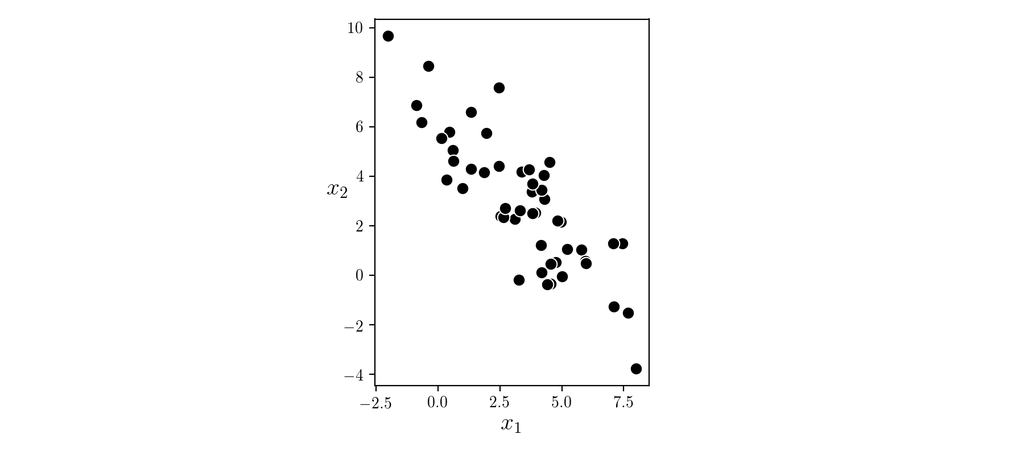

Now we can implement the least squares cost function in equation (4). To stay consistent with our style for implementing cost functions, we will input package the weights for $\mathbf{C}$ and $\mathbf{W}$ in a single input list `w` as `w = [C,W]`. Once inside the cost function we can then simply strip off each matrix of weights and compute the cost function, as shown below in the implementation.

```python
# an implementation of the least squares cost function for PCA
# here the weight matrices are loaded in a single list w = [C,W]
def least_squares(w):
    # strip off C and W parameters
    C = w[0]
    W = w[1]

    # compute the least squares cost
    cost = np.sum((np.dot(C,W) - X)**2)
    return cost/float(X.shape[1])
```

Now make a run of $100$ gradient descent steps with a fixed steplength parameter $\alpha = 1$ for all steps in order to minimize the PCA Least Squares cost function implemented above. Here we use the implementation of gradient descent given in [Section 3.6](https://jermwatt.github.io/machine_learning_refined/notes/3_First_order_methods/3_6_Descent.html), which we employ via a backend file.

With our gradient descent run complete we can plot the associated cost function history to make sure the method has converged sufficiently for our settings. We do this below.

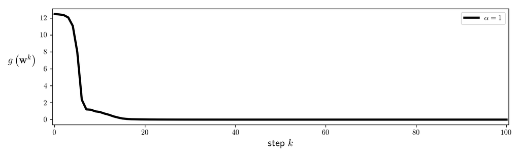

In the left panel below we plot our best recovered basis (from the final step of the run above) along with the original data. Here the two basis vectors - shown as red arrows - are essentially two random vectors in the plane. Essentially any two random vectors will do here since they will span the entire space of the data, giving a perfect representation. In the right panel we plot the encoded version of the data - i.e., the associated learned weight vectors $\mathbf{w}_p$ (see the previous Section if this nomenclature is unfamiliar).

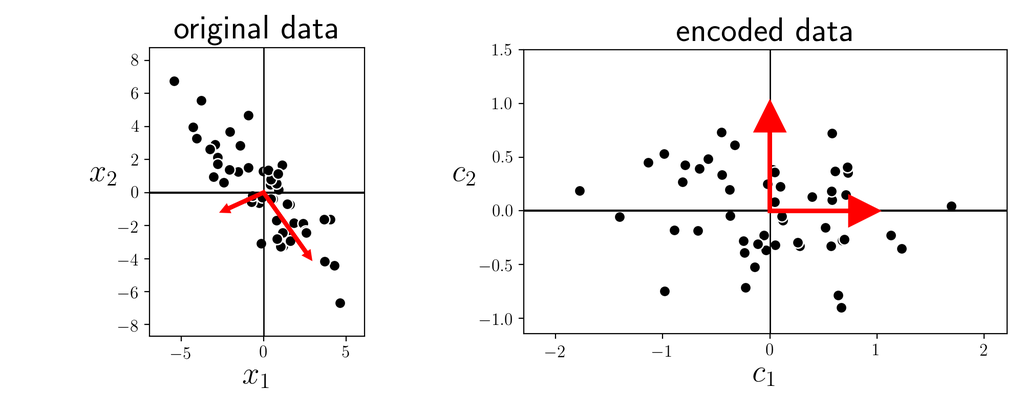

To empirically validate (at least to some degree) the notion that proper minimization will - in this instance - recover essentially any two random vectors, we show the results of three more runs of gradient descent using the same parameters as above but with a random initialization in each instance. We plot the best recovered basis in each instance afterwards, and as we can see each instance differs considerably from the others (recovering two linearly independent vectors in each case).

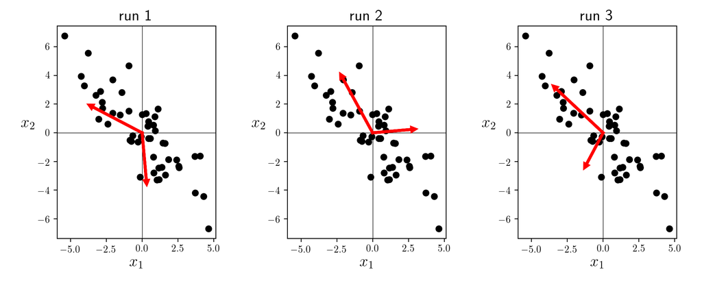

#### Example 2: Learning a proper subspace via gradient descent

In this example we use gradient descent to minimize the PCA Least Squares cost in order to learn the best two-dimensional subspace representation of an $N=3$ dimensional dataset consisting of $100$ points. We load in the dataset below and mean-center it.

Now we make a run of $100$ gradient descent steps with a fixed steplength value of $\alpha = 1$ for each step. With these settings gradient descent converges very well. Notice: to learn $2$ basis elements we initialize $\mathbf{C}$ as a random $3 \times 2 $ matrix (i.e., it will have only two spanning vectors), and likewise initialize each weight vector to have only two entries.

With this run complete we can plot our two learned spanning vectors $\mathbf{c}_1$ and $\mathbf{c}_2$, the two-dimensional subspace it spans, etc., We do this below. The left panel shows the original data (as gray dots), learned spanning vectors (shown as red arrows), and corresponding subspace colored in light red. This is the very best two-dimensional subspace representation for the input data. In the middle panel we show the corresponding learned weight vectors / encodings $\mathbf{w}_p$ of the original input $\mathbf{x}_p$ in the space spanned by the recovered spanning vectors. In the right panel we show the original data space again and the decoded data points (gray dots with red borders) - i.e., the projection of each datapoint onto the space spanned by our learned basis. As detailed in the previous Section the decoded version of the $p^{th}$ point $\mathbf{x}_p$ is computed as $\mathbf{C}\mathbf{w}_p$, where $\mathbf{C}$ and $\mathbf{w}_p$ are the fully learned basis and encoding for the $p^{th}$ point.

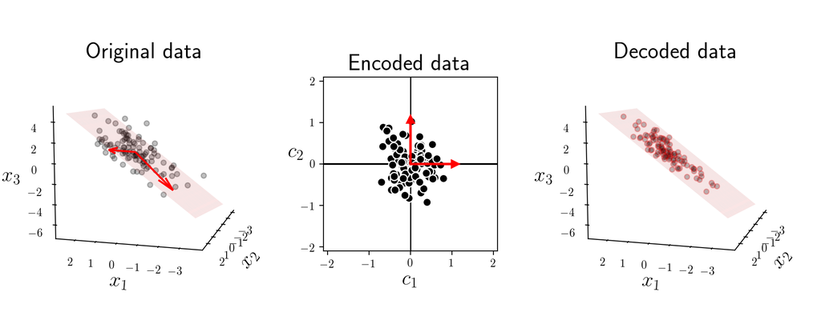